# Marketing Assignment 2

Bo Gu, Ke Deng, Lingyi Zhao

2021-02-21

## R Markdown

Loading in the data for the two datasets to understand what they contain.

```r
#install.packages("conjoint")
library(conjoint)
#data(journey)
data(chocolate)
```

**Journey** is a dataset around travel. The variables used in the conjoint analysis will be purpose w/ 4 levels(cognitive, vacation, health, business), form w/ 2 levels (organized vs. own), season w/ 2 levels (summer vs. winter), and accomodation w/ 4 levels (1-2-3 star_hotel, 4-5 star_hotel, guesthouse, hostel).

**Chocolate** is a dataset around chocolate. The variables used in the conjoint analysis will be kind w/ 4 levels (milk,walnut, delicaties, dark), price w/ 3 levels(low, average, and high), packing w/ 2 levels (paperback vs. hardback),weight w/ 3 levels (light, middle, heavy) and calorie w/ 2 levels (little vs. much)

description of the data provided in data(chocolate):

**cpref** = Vector of preferences (ratings) only - length 1392 (87 respondents x each respondent shown 16 profiles=1392). **cprefm** = Matrix of preferences (87 respondents and 16 profiles). **cprof** = Matrix of profiles (5 attributes and 16 full profiles). **clevn** = Character vector of names for the attributes’ levels. **csimp** = Matrix of simulation profiles.

#### PART 1

Use journey or chocolate data from package conjoint. Perform the following analyses:

- Partworth estimation for all individuals separately
- Partworth estimation by combining all individual responses into an aggregate
- Partworth estimation by using linear mixed models. In this case, you should treat each individual as a separate group for defining the random effects
- Partworth estimation of the mixed effects models by using MCMChregress

```r
set.seed(225)

#Randomly selecting the holdout data for the test dataframe
holdout <- vector()

#Randomly assigning 1-16 to each of the survey respondents 16 profiles
for (x in 1:87){
  j <- sample(1:16)
  holdout <- c(holdout,j)}

# adding in a response id column to identify each respondent - each respondent has a preference rating for 16 profiles
respid<- vector()
for (x in 1:87){
  j <- rep(x,16)
  respid <- c(respid,j)}

#establishing an inital dataframe
cprof.full <- cprof

#adding in cprof an additional 86 times, so cprof is repeated 87 times in cprof.full

for (x in 1:86){
  cprof.full <- rbind(cprof.full,cprof)}

#creating a dataframe that includes all respondents with their 16 profiles and preferences stacked on top of each other.

full.data <- data.frame(cbind(cpref, holdout, cprof.full,respid))

#to randomly remove 2 profiles per respondent going to use the randomly generated holdout data and just take the profiles where the holdout is 3-16 for the train and the test is 1 and 2.

train.data <- full.data[full.data$holdout>2,]
test.data <- full.data[full.data$holdout<3,]
```

```r
#Model 1 - Individual Model
coeff <- matrix(nrow=87, ncol=15,dimnames = list(c(1:87),c('Constant',t(clevn))))
pred<- numeric()

#looping through individual lm models and taking the coefficients into a separate dataframe

cprof.factor=data.frame(apply(cprof,2,factor))

des.mm= model.matrix(~kind + price + packing + weight + calorie, data = cprof.factor,
              contrasts.arg=list(kind=contr.sum,price=contr.sum,
                                 packing=contr.sum,weight=contr.sum, calorie=contr.sum))

des.mm.full <- des.mm

for (x in 1:86){
  des.mm.full <- rbind(des.mm.full,des.mm)
  }

des.df.full <- data.frame(des.mm.full)

chocolate <- data.frame(cbind(cpref, holdout,des.df.full,respid))
rownames(chocolate) <- 1:nrow(chocolate)

cho.train.data <- chocolate[chocolate$holdout>2,]
cho.test.data <- chocolate[chocolate$holdout<3,]

for (i in 1:87){
  model = lm(pref~kind1+kind2+kind3+price1+price2+packing1+weight1+weight2+calorie1, data = cho.train.data[cho.train.data$respid == i,])

  yhat = predict(model,cho.test.data[cho.test.data$respid == i,])
  pred = c(pred,yhat)
  coeff[i,1:4]=model$coefficients[1:4]
  coeff[i,5]=-sum(model$coefficients[2:4])
  coeff[i,6:7]=model$coefficients[5:6]
  coeff[i,8]=-sum(model$coefficients[5:6])
  coeff[i,9]=model$coefficients[7]
  coeff[i,10]=-model$coefficients[7]
  coeff[i,11:12]=model$coefficients[8:9]
  coeff[i,13]=-sum(model$coefficients[8:9])
  coeff[i,14]=model$coefficients[10]
  coeff[i,15]=-model$coefficients[10]
  }

# Write your code to run the individual lm models

mse_part1 <- mean(test.data$pref-pred)^2
mse_part1
```

```
## [1] 0.01876131
```

```r
#Model 2 - Aggregate Model
#running full lm on all respondents and profiles as this is an aggregate model
#all respondents have the same coefficients

model_p2 = lm(pref~kind1+kind2+kind3+price1+price2+packing1+weight1+weight2+calorie1, data = cho.train.data)

summary(model_p2)
```

```
##
## Call:
## lm(formula = pref ~ kind1 + kind2 + kind3 + price1 + price2 +
##     packing1 + weight1 + weight2 + calorie1, data = cho.train.data)
##
## Residuals:
##      Min       1Q   Median       3Q      Max
## -11.6803  -3.6382   0.5029   3.3197   9.6958
##
## Coefficients:
##             Estimate Std. Error t value Pr(>|t|)
## (Intercept)  8.68845    0.13485  64.431  < 2e-16 ***
## kind1       -1.10360    0.21033  -5.247 1.83e-07 ***
## kind2       -0.80161    0.21350  -3.755 0.000182 ***
## kind3       -0.91070    0.21147  -4.307 1.79e-05 ***
## price1      -0.63238    0.16287  -3.883 0.000109 ***
## price2       0.03155    0.19017   0.166 0.868263
## packing1     0.02187    0.12220   0.179 0.857993
## weight1     -0.05843    0.16289  -0.359 0.719864
## weight2      0.12115    0.18977   0.638 0.523323
## calorie1    -0.61168    0.12221  -5.005 6.40e-07 ***
## ---
## Signif. codes:  0 '***' 0.001 '**' 0.01 '*' 0.05 '.' 0.1 ' ' 1
##
## Residual standard error: 4.263 on 1208 degrees of freedom
## Multiple R-squared:  0.1533, Adjusted R-squared:  0.1469
## F-statistic: 24.29 on 9 and 1208 DF,  p-value: < 2.2e-16
```

```r
model_p2.parthworth <- model_p2$coefficients

model_p2.parthworth['kind4']=-sum(model_p2.parthworth['kind1'],model_p2.parthworth['kind2'],model_p2.parthworth['kind3'])
model_p2.parthworth['price3']=-sum(model_p2.parthworth['price1'],model_p2.parthworth['price2'])
model_p2.parthworth['packing2']=-sum(model_p2.parthworth['packing1'])
model_p2.parthworth['weight3']=-sum(model_p2.parthworth['weight1'],model_p2.parthworth['weight2'])
model_p2.parthworth['calorie2']=-sum(model_p2.parthworth['calorie1'])

model_p2_pred <- predict(model_p2,cho.test.data)


mse_part2 <- mean(test.data$pref-model_p2_pred)^2
mse_part2
```

```
## [1] 0.01586616
```

```r
#Model 3 - Mixed Models Approach
require(lme4)
model_p3 <- lmer(pref~kind1+kind2+kind3+price1+price2+packing1+weight1+weight2+calorie1 +
       (1+kind1+kind2+kind3+price1+price2+packing1+weight1+weight2+calorie1|respid),
     control=lmerControl(optCtrl = list(maxfun=100000)), data=cho.train.data)
model_p3.parthworth <- matrix(nrow=87, ncol=15,dimnames = list(c(1:87),c('Constant',t(clevn))))

model_p3.coef <- coef(model_p3)$respid

for (i in 1:87){
  model_p3.parthworth[i,1]=model_p3.coef$`(Intercept)`[i]
  model_p3.parthworth[i,2]=model_p3.coef$kind1[i]
  model_p3.parthworth[i,3]=model_p3.coef$kind2[i]
  model_p3.parthworth[i,4]=model_p3.coef$kind3[i]
  model_p3.parthworth[i,5]=-sum(model_p3.parthworth[i,2:4])
  model_p3.parthworth[i,6]=model_p3.coef$price1[i]
  model_p3.parthworth[i,7]=model_p3.coef$price2[i]
  model_p3.parthworth[i,8]=-sum(model_p3.parthworth[i,6:7])
  model_p3.parthworth[i,9]=model_p3.coef$packing1[i]
  model_p3.parthworth[i,10]=-model_p3.parthworth[i,9]
  model_p3.parthworth[i,11]=model_p3.coef$weight1[i]
  model_p3.parthworth[i,12]=model_p3.coef$weight2[i]
  model_p3.parthworth[i,13]=-sum(model_p3.parthworth[i,11:12])
  model_p3.parthworth[i,14]=model_p3.coef$calorie1[i]
  model_p3.parthworth[i,15]=-model_p3.parthworth[i,14]
}

model_p3_pred <- predict(model_p3, cho.test.data)

mse_part3 <- mean(test.data$pref-model_p3_pred)^2
mse_part3
```

```
## [1] 0.005880283
```

```r
#Model 4 - MCMC

require(MCMCpack)
model_p4 <- MCMChregress (fixed = pref~kind1+kind2+kind3+price1+price2+packing1+weight1+weight2+calorie1,
                          random =  ~1+kind1+kind2+kind3+price1+price2+packing1+weight1+weight2+calorie1,
                          group="respid",r=10, R=10*diag(10),data=cho.train.data)
```

```
##
## Running the Gibbs sampler. It may be long, keep cool :)
##
## **********:10.0%
## **********:20.0%
## **********:30.0%
## **********:40.0%
## **********:50.0%
## **********:60.0%
## **********:70.0%
## **********:80.0%
## **********:90.0%
## **********:100.0%
```

```r
#finding the fixed effects by taking the mean of the 1,000 simulations
fixed.intercept = mean(model_p4$mcmc[1:1000,1])
fixed.kind1 = mean(model_p4$mcmc[1:1000,2])
fixed.kind2 = mean(model_p4$mcmc[1:1000,3])
fixed.kind3 = mean(model_p4$mcmc[1:1000,4])
fixed.price1 = mean(model_p4$mcmc[1:1000,5])
fixed.price2 = mean(model_p4$mcmc[1:1000,6])
fixed.packing1 = mean(model_p4$mcmc[1:1000,7])
fixed.weight1 = mean(model_p4$mcmc[1:1000,8])
fixed.weight2 = mean(model_p4$mcmc[1:1000,9])
fixed.calorie1 = mean(model_p4$mcmc[1:1000,10])

model_p4_coeff=data.frame()

for (i in 1:87)
{
  #creating the variable name for the random effects, which are unique to respondent

  v1= mean(model_p4$mcmc[,paste("b.(Intercept).",as.character(i),sep = '')])
  v2= model_p4$mcmc[,paste("b.kind1.",as.character(i),sep = '')]
  v3= model_p4$mcmc[,paste("b.kind2.",as.character(i),sep = '')]
  v4= model_p4$mcmc[,paste("b.kind3.",as.character(i),sep = '')]
  v5= model_p4$mcmc[,paste("b.price1.",as.character(i),sep = '')]
  v6= model_p4$mcmc[,paste("b.price2.",as.character(i),sep = '')]
  v7= model_p4$mcmc[,paste("b.packing1.",as.character(i),sep = '')]
  v8= model_p4$mcmc[,paste("b.weight1.",as.character(i),sep = '')]
  v9= model_p4$mcmc[,paste("b.weight2.",as.character(i),sep = '')]
  v10= model_p4$mcmc[,paste("b.calorie1.",as.character(i),sep = '')]

  #taking the mean of the individual variables to find the random effects and adding the fixed effects
  model_p4_coeff[i,1] = mean(v1)+ fixed.intercept
  model_p4_coeff[i,2] = mean(v2)+ fixed.kind1
  model_p4_coeff[i,3] = mean(v3)+ fixed.kind2
  model_p4_coeff[i,4] = mean(v4)+ fixed.kind3
  model_p4_coeff[i,5] = mean(v5)+ fixed.price1
  model_p4_coeff[i,6] = mean(v6)+ fixed.price2
  model_p4_coeff[i,7] = mean(v7)+ fixed.packing1
  model_p4_coeff[i,8] = mean(v8)+ fixed.weight1
  model_p4_coeff[i,9] = mean(v9)+ fixed.weight2
  model_p4_coeff[i,10] = mean(v10)+ fixed.calorie1
}

model_p4.parthworth <- matrix(nrow=87, ncol=15,dimnames = list(c(1:87),c('Constant',t(clevn))))


for (i in 1:87){
  model_p4.parthworth[i,1]=model_p4_coeff$V1[i]
  model_p4.parthworth[i,2]=model_p4_coeff$V2[i]
  model_p4.parthworth[i,3]=model_p4_coeff$V3[i]
  model_p4.parthworth[i,4]=model_p4_coeff$V4[i]
  model_p4.parthworth[i,5]=-sum(model_p4.parthworth[i,2:4])
  model_p4.parthworth[i,6]=model_p4_coeff$V5[i]
  model_p4.parthworth[i,7]=model_p4_coeff$V6[i]
  model_p4.parthworth[i,8]=-sum(model_p4.parthworth[i,6:7])
  model_p4.parthworth[i,9]=model_p4_coeff$V7[i]
  model_p4.parthworth[i,10]=-model_p4.parthworth[i,9]
  model_p4.parthworth[i,11]=model_p4_coeff$V8[i]
  model_p4.parthworth[i,12]=model_p4_coeff$V9[i]
  model_p4.parthworth[i,13]=-sum(model_p4.parthworth[i,11:12])
  model_p4.parthworth[i,14]=model_p4_coeff$V10[i]
  model_p4.parthworth[i,15]=-model_p4.parthworth[i,14]
}

#generating the predictions by looping through and multiplying by the coefficients
model_p4_coeff_test = rbind(model_p4_coeff[1,],model_p4_coeff[1,])

for( i in 2:87){
  model_p4_coeff_test = rbind(model_p4_coeff_test,model_p4_coeff[i,],model_p4_coeff[i,])
}

model_p4_pred <- numeric()

# How will you score the test profiles in MCMC ?

for (i in 1:174){
  model_p4_pred[i] =  model_p4_coeff_test[i,1]+
                      model_p4_coeff_test[i,2]*cho.test.data[i,4]+
                      model_p4_coeff_test[i,3]*cho.test.data[i,5]+
                      model_p4_coeff_test[i,4]*cho.test.data[i,6]+
                      model_p4_coeff_test[i,5]*cho.test.data[i,7]+
                      model_p4_coeff_test[i,6]*cho.test.data[i,8]+
                      model_p4_coeff_test[i,7]*cho.test.data[i,9]+
                      model_p4_coeff_test[i,8]*cho.test.data[i,10]+
                      model_p4_coeff_test[i,9]*cho.test.data[i,11]+
                      model_p4_coeff_test[i,10]*cho.test.data[i,12]
}

mse_part4 <- mean(test.data$pref-model_p4_pred)^2
mse_part4
```

```
## [1] 0.01850255
```

### Part 2

#### Compare the performance of the 4 models

```r
data.frame(mse_part1,mse_part2,mse_part3,mse_part4)
```

| mse_part1 | mse_part2 | mse_part3 | mse_part4 |
| --- | --- | --- | --- |
| 0.01876131 | 0.01586616 | 0.005880283 | 0.01850255 |

Based on the four models, the model with the lowest mse is **Model 3 - Mixed Models Approach**

### Part 3

Now we will cluster the part-worths of the **Model 3 - Mixed Models Approach**.

```r
# Choose the coefficient from the best model based on test data performance
partworths <- coef(model_p3)$respid

# Perform Clustering
k.max <- 6
data <- partworths
wss <- sapply(1:k.max,
              function(k){kmeans(data, k, nstart=50,iter.max = 15 )$tot.withinss})
wss
```

```
## [1] 2300.0376 1520.5202 1203.7589 1018.7983  872.0118  747.9045
```

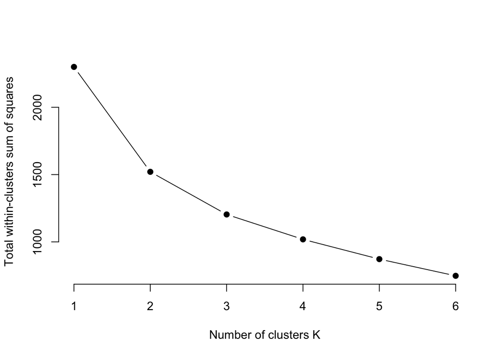

```r
plot(1:k.max, wss,
     type="b", pch = 19, frame = FALSE,
     xlab="Number of clusters K",
     ylab="Total within-clusters sum of squares")
```

**Based on the elbow method, we choose k=3.**

```r
kmm = kmeans(data,3,nstart = 50,iter.max = 15)
kmm
```

```
## K-means clustering with 3 clusters of sizes 26, 34, 27
##
## Cluster means:
##   (Intercept)     kind1     kind2     kind3     price1      price2     packing1
## 1    8.629357  1.519921 -2.091962 -3.558923 -0.4349114  0.16963866 -0.008769924
## 2    8.732646 -1.842281  1.223047 -1.847085 -0.7721856 -0.09355367 -0.023064673
## 3    8.667624 -2.606807 -2.069099  2.881286 -0.4981399  0.17684793  0.023032766
##       weight1     weight2   calorie1
## 1 -0.05620952  0.20581897 -0.3377524
## 2 -0.05619202  0.20284565 -0.9576237
## 3 -0.20284526 -0.05605476 -0.5293450
##
## Clustering vector:
##  1  2  3  4  5  6  7  8  9 10 11 12 13 14 15 16 17 18 19 20 21 22 23 24 25 26
##  3  1  2  2  2  3  2  2  1  1  1  3  2  3  3  1  3  1  3  3  2  1  1  1  2  1
## 27 28 29 30 31 32 33 34 35 36 37 38 39 40 41 42 43 44 45 46 47 48 49 50 51 52
##  2  3  3  1  2  3  3  2  3  1  2  3  2  3  1  2  1  2  3  3  2  3  1  1  3  3
## 53 54 55 56 57 58 59 60 61 62 63 64 65 66 67 68 69 70 71 72 73 74 75 76 77 78
##  2  2  3  3  2  2  1  3  2  3  2  1  3  1  3  2  3  1  2  1  2  1  1  2  2  2
## 79 80 81 82 83 84 85 86 87
##  1  2  2  2  2  1  2  1  2
##
## Within cluster sum of squares by cluster:
## [1] 300.1408 515.4705 388.1476
##  (between_SS / total_SS =  47.7 %)
##
## Available components:
##
## [1] "cluster"      "centers"      "totss"        "withinss"     "tot.withinss"
## [6] "betweenss"    "size"         "iter"         "ifault"
```

**After the k-means clustering, there are 26 respondants in cluster 1, 34 respondants in cluster 2, 27 respondants in cluster 3.**

### Part 4

Build a simulator that takes as input 4 or 5 input concepts, and produces market share estimates. Function caLogit can be used from package conjoint.

```r
##First, we build a dataframe of the profiles we want to use as inputs (calling this dataframe 'csimp0').

csimp0 <- data.frame(kind=c(4,1,2,3,2),
                     price=c(1,3,2,1,3),
                     packing=c(2,1,1,1,2),
                     weight=c(2,1,3,1,3),
                     calorie=c(1,2,1,1,2))

##Here we can see what the dataframe looks like.
print(csimp0)
```

```
##   kind price packing weight calorie
## 1    4     1       2      2       1
## 2    1     3       1      1       2
## 3    2     2       1      3       1
## 4    3     1       1      1       1
## 5    2     3       2      3       2
```

```r
#Then we run caLogit using 'csimp0' as our matrix of simulation profiles, along with the cpref and cprof given in the chocolate data. These are the market share estimates.

caLogit(csimp0,cpref,cprof)
```

```
## [1] 47.927888 14.484307  8.922716 11.965447 16.699642
```

### Part 5

**Cluster 1**

```r
cluster1 = kmm$centers[1,]
cluster1['kind4']= -sum(cluster1['kind1'], cluster1['kind2'], cluster1['kind3'])
cluster1['price3']=-sum(cluster1['price1'],cluster1['price2'])
cluster1['packing2']=-sum(cluster1['packing1'])
cluster1['weight3']=-sum(cluster1['weight1'],cluster1['weight2'])
cluster1['calorie2']=-sum(cluster1['calorie1'])
order(cluster1)
```

```
##  [1]  4  3  5 10 14  8  7 13  6  9 12 15  2 11  1
```

```r
cluster1[order(-cluster1)]
```

```
##  (Intercept)        kind4        kind1     calorie2       price3      weight2
##  8.629356619  4.130963733  1.519920727  0.337752402  0.265272782  0.205818966
##       price2     packing2     packing1      weight1      weight3     calorie1
##  0.169638663  0.008769924 -0.008769924 -0.056209519 -0.149609447 -0.337752402
##       price1        kind2        kind3
## -0.434911444 -2.091961711 -3.558922750
```

```r
cluster1.kind.importance = max(cluster1['kind1'],cluster1['kind2'],cluster1['kind3'],cluster1['kind4'])-min(cluster1['kind1'],cluster1['kind2'],cluster1['kind3'],cluster1['kind4'])
cluster1.price.importance= max(cluster1['price1'],cluster1['price2'],cluster1['price3'])-min(cluster1['price1'],cluster1['price2'],cluster1['price3'])
cluster1.packing.importance= max(cluster1['packing1'],cluster1['packing2'])-min(cluster1['packing1'],cluster1['packing2'])
cluster1.weight.importance= max(cluster1['weight1'],cluster1['weight2'],cluster1['weight3'])-min(cluster1['weight1'],cluster1['weight2'],cluster1['weight3'])
cluster1.calorie.importance= max(cluster1['calorie1'],cluster1['calorie2'])-min(cluster1['calorie1'],cluster1['calorie2'])

cluster1.attribute.importance = cbind(cluster1.kind.importance, cluster1.packing.importance, cluster1.price.importance,cluster1.weight.importance,cluster1.calorie.importance)
cluster1.attribute.importance
```

```
##      cluster1.kind.importance cluster1.packing.importance
## [1,]                 7.689886                  0.01753985
##      cluster1.price.importance cluster1.weight.importance
## [1,]                 0.7001842                  0.3554284
##      cluster1.calorie.importance
## [1,]                   0.6755048
```

**Importance Ranking: kind > price > calorie > weight> packing**

**Top 5 profile in cluster 1:**

- Profile 1: dark, high price, much calorie, middle weight, hardback chocolate
- Profile 2: dark, high price, much calorie, middle weight, paperback chocolate
- Profile 3: dark, high price, much calorie, low weight, hardback chocolate
- Profile 4: dark, high price, much calorie, low weight, paperback chocolate
- Profile 5: dark, high price, much calorie, high weight, hardback chocolate

**Cluster 2**

```r
kmm$centers[2,]
```

```
## (Intercept)       kind1       kind2       kind3      price1      price2
##  8.73264576 -1.84228117  1.22304676 -1.84708530 -0.77218562 -0.09355367
##    packing1     weight1     weight2    calorie1
## -0.02306467 -0.05619202  0.20284565 -0.95762367
```

```r
cluster2 = kmm$centers[2,]
cluster2['kind4']= -sum(cluster2['kind1'], cluster2['kind2'], cluster2['kind3'])
cluster2['price3']=-sum(cluster2['price1'],cluster2['price2'])
cluster2['packing2']=-sum(cluster2['packing1'])
cluster2['weight3']=-sum(cluster2['weight1'],cluster2['weight2'])
cluster2['calorie2']=-sum(cluster2['calorie1'])
order(cluster2)
```

```
##  [1]  4  2 10  5 14  6  8  7 13  9 12 15  3 11  1
```

```r
cluster2[order(-cluster2)]
```

```
## (Intercept)       kind4       kind2    calorie2      price3     weight2
##  8.73264576  2.46631971  1.22304676  0.95762367  0.86573929  0.20284565
##    packing2    packing1     weight1      price2     weight3      price1
##  0.02306467 -0.02306467 -0.05619202 -0.09355367 -0.14665363 -0.77218562
##    calorie1       kind1       kind3
## -0.95762367 -1.84228117 -1.84708530
```

```r
cluster2.kind.importance = max(cluster2['kind1'],cluster2['kind2'],cluster2['kind3'],cluster2['kind4'])-min(cluster2['kind1'],cluster2['kind2'],cluster2['kind3'],cluster2['kind4'])
cluster2.price.importance= max(cluster2['price1'],cluster2['price2'],cluster2['price3'])-min(cluster2['price1'],cluster2['price2'],cluster2['price3'])
cluster2.packing.importance= max(cluster2['packing1'],cluster2['packing2'])-min(cluster2['packing1'],cluster2['packing2'])
cluster2.weight.importance= max(cluster2['weight1'],cluster2['weight2'],cluster2['weight3'])-min(cluster2['weight1'],cluster2['weight2'],cluster2['weight3'])
cluster2.calorie.importance= max(cluster2['calorie1'],cluster2['calorie2'])-min(cluster2['calorie1'],cluster2['calorie2'])

cluster2.attribute.importance = cbind(cluster2.kind.importance, cluster2.packing.importance, cluster2.price.importance,cluster2.weight.importance,cluster2.calorie.importance)
cluster2.attribute.importance
```

```
##      cluster2.kind.importance cluster2.packing.importance
## [1,]                 4.313405                  0.04612935
##      cluster2.price.importance cluster2.weight.importance
## [1,]                  1.637925                  0.3494993
##      cluster2.calorie.importance
## [1,]                    1.915247
```

**Importance Ranking: kind > calorie > price > weight> packing**

**Top 5 profile in cluster 2:**

- Profile 1: dark, much calorie, high price, middle weight, hardback chocolate
- Profile 2: dark, much calorie, high price, middle weight, paperback chocolate
- Profile 3: dark, much calorie, high price, low weight, hardback chocolate
- Profile 4: dark, much calorie, high price, low weight, paperback chocolate
- Profile 5: dark, much calorie, high price, high weight, hardback chocolate

**Cluster3**

```r
cluster3 = kmm$centers[3,]
cluster3['kind4']= -sum(cluster3['kind1'], cluster3['kind2'], cluster3['kind3'])
cluster3['price3']=-sum(cluster3['price1'],cluster3['price2'])
cluster3['packing2']=-sum(cluster3['packing1'])
cluster3['weight3']=-sum(cluster3['weight1'],cluster3['weight2'])
cluster3['calorie2']=-sum(cluster3['calorie1'])
order(cluster3)
```

```
##  [1]  2  3 10  5  8  9 13  7  6 14 12 15 11  4  1
```

```r
cluster3[order(-cluster3)]
```

```
## (Intercept)       kind3       kind4    calorie2      price3     weight3
##  8.66762392  2.88128636  1.79461906  0.52934502  0.32129198  0.25890001
##      price2    packing1    packing2     weight2     weight1      price1
##  0.17684793  0.02303277 -0.02303277 -0.05605476 -0.20284526 -0.49813992
##    calorie1       kind2       kind1
## -0.52934502 -2.06909857 -2.60680685
```

```r
cluster3.kind.importance = max(cluster3['kind1'],cluster3['kind2'],cluster3['kind3'],cluster3['kind4'])-min(cluster3['kind1'],cluster3['kind2'],cluster3['kind3'],cluster3['kind4'])
cluster3.price.importance= max(cluster3['price1'],cluster3['price2'],cluster3['price3'])-min(cluster3['price1'],cluster3['price2'],cluster3['price3'])
cluster3.packing.importance= max(cluster3['packing1'],cluster3['packing2'])-min(cluster3['packing1'],cluster3['packing2'])
cluster3.weight.importance= max(cluster3['weight1'],cluster3['weight2'],cluster3['weight3'])-min(cluster3['weight1'],cluster3['weight2'],cluster3['weight3'])
cluster3.calorie.importance= max(cluster3['calorie1'],cluster3['calorie2'])-min(cluster3['calorie1'],cluster3['calorie2'])

cluster3.attribute.importance = cbind(cluster3.kind.importance, cluster3.packing.importance, cluster3.price.importance,cluster3.weight.importance,cluster3.calorie.importance)
cluster3.attribute.importance
```

```
##      cluster3.kind.importance cluster3.packing.importance
## [1,]                 5.488093                  0.04606553
##      cluster3.price.importance cluster3.weight.importance
## [1,]                 0.8194319                  0.4617453
##      cluster3.calorie.importance
## [1,]                     1.05869
```

**Importance Ranking: kind > calorie > price > weight> packing**

**Top 5 profile in cluster 3:**

- Profile 1: delicaties, much calorie, high price, heavy weight, paperback chocolate
- Profile 2: delicaties, much calorie, high price, heavy weight, haedback chocolate
- Profile 3: delicaties, much calorie, high price, middle weight, paperback chocolate
- Profile 4: delicaties, much calorie, high price, middle weight, hardback chocolate
- Profile 5: delicaties, much calorie, high price, low weight, paperback chocolate